# Exploratory Data Analysis

Abdul Majid

February 3, 2022

##### NOTE:

1. Change author name and date to your exercise submission date in above section
2. Your code MUST execute without errors.
3. You can add more lines in your code as required.

## Section 1: Summary Statistics

### Question 1

**The dataset is loaded for you. Perform the following tasks:**

1. Using the airquality dataset, generate the five-point summary through the appropriate function.
2. Visualize the data for temperature through histogram. Add color and labels.
3. Visualize the distribution of data for Wind. Add colors and labels.
4. Visualize the relationship between Solar.R and Ozone. Use scatterplot and circular red markers to identify the points.

```r
library(datasets)
head(airquality)
```

```
##   Ozone Solar.R Wind Temp Month Day
## 1    41     190  7.4   67     5   1
## 2    36     118  8.0   72     5   2
## 3    12     149 12.6   74     5   3
## 4    18     313 11.5   62     5   4
## 5    NA      NA 14.3   56     5   5
## 6    28      NA 14.9   66     5   6
```

```r
summary(airquality)
```

```
##      Ozone           Solar.R           Wind             Temp
##  Min.   :  1.00   Min.   :  7.0   Min.   : 1.700   Min.   :56.00
##  1st Qu.: 18.00   1st Qu.:115.8   1st Qu.: 7.400   1st Qu.:72.00
##  Median : 31.50   Median :205.0   Median : 9.700   Median :79.00
##  Mean   : 42.13   Mean   :185.9   Mean   : 9.958   Mean   :77.88
##  3rd Qu.: 63.25   3rd Qu.:258.8   3rd Qu.:11.500   3rd Qu.:85.00
##  Max.   :168.00   Max.   :334.0   Max.   :20.700   Max.   :97.00
##  NA's   :37       NA's   :7
##      Month            Day
##  Min.   :5.000   Min.   : 1.0
##  1st Qu.:6.000   1st Qu.: 8.0
##  Median :7.000   Median :16.0
##  Mean   :6.993   Mean   :15.8
##  3rd Qu.:8.000   3rd Qu.:23.0
##  Max.   :9.000   Max.   :31.0
##
```

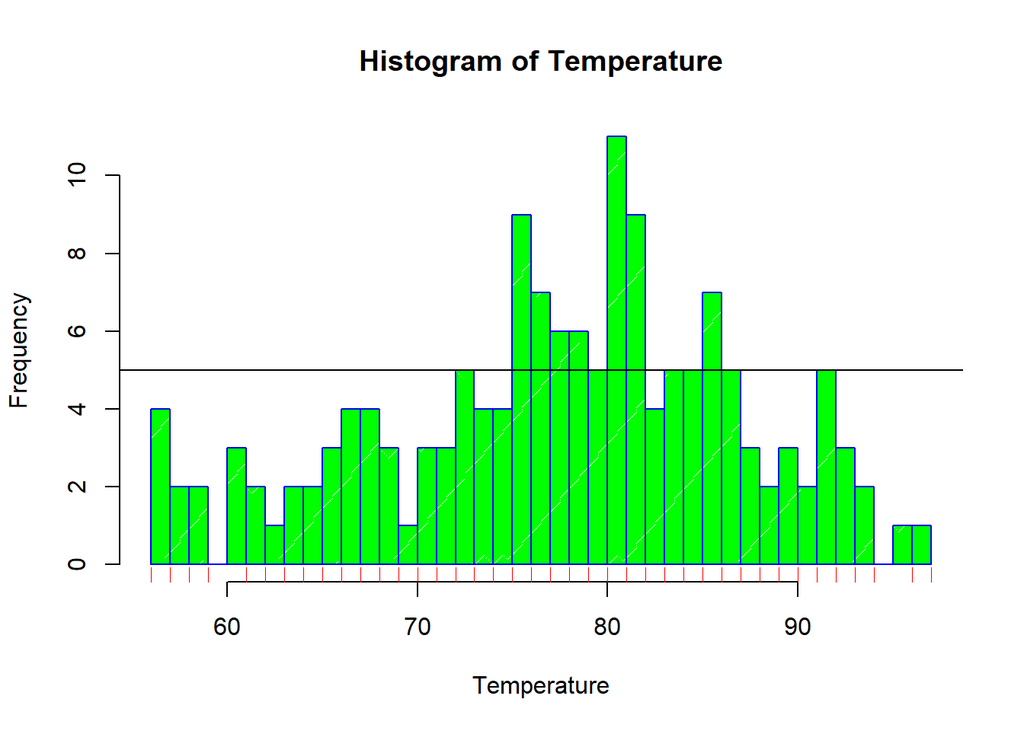

```r
{
  hist(airquality$Temp, breaks=40, col="green", border = "blue", main="Histogram of Temperature", xlab="Temperature", ylab="Frequency", density = 90)
  abline(h=5)
  rug(airquality$Temp, side = 1, col="red")
}
```

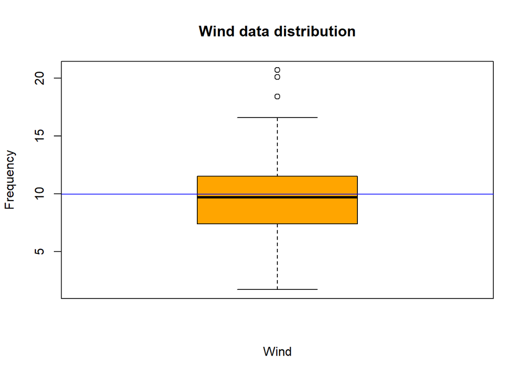

```r
{
  boxplot(airquality$Wind, col='orange', xlab = "Wind", ylab = "Frequency", main = "Wind data distribution")
  abline(h=mean(airquality$Wind), col='blue')
}
```

[figure not shown]

```r
data <- airquality
plot(data$Solar.R, data$Ozone, xlab = "Ozone", ylab="Solar.R", pch=19, col='red')
```